# Risk Factor Analysis

## Outcome Variable

**Outcome Variable:** ever_wasted

## Predictor Variables

**Intervention Variable:** exclfeed3

**Adjustment Set:**

- arm
- sex
- brthmon
- W_mage
- meducyrs
- feducyrs
- hhwealth_quart
- hfoodsec
- W_mhtcm
- W_mwtkg
- W_mbmi
- vagbrth
- W_gagebrth
- W_birthwt
- W_birthlen
- W_nrooms
- W_nchldlt5
- month
- W_parity
- impfloor
- impsan
- safeh20
- delta_W_mage
- delta_meducyrs
- delta_feducyrs
- delta_hhwealth_quart
- delta_hfoodsec
- delta_W_mhtcm
- delta_W_mwtkg
- delta_W_mbmi
- delta_vagbrth
- delta_W_gagebrth
- delta_W_birthwt
- delta_W_birthlen
- delta_W_nrooms
- delta_W_nchldlt5
- delta_month
- delta_W_parity
- delta_impfloor
- delta_impsan
- delta_safeh20

## Stratifying Variables

The analysis was stratified on these variable(s):

- agecat
- studyid
- country

## Data Summary

| agecat | studyid | country | exclfeed3 | ever_wasted | n_cell | n |
| --- | --- | --- | --- | --- | --- | --- |
| 0-24 months (no birth wast) | ki0047075b-MAL-ED | BANGLADESH | 1 | 0 | 123 | 244 |
| 0-24 months (no birth wast) | ki0047075b-MAL-ED | BANGLADESH | 1 | 1 | 36 | 244 |
| 0-24 months (no birth wast) | ki0047075b-MAL-ED | BANGLADESH | 0 | 0 | 66 | 244 |
| 0-24 months (no birth wast) | ki0047075b-MAL-ED | BANGLADESH | 0 | 1 | 19 | 244 |
| 0-24 months (no birth wast) | ki0047075b-MAL-ED | BRAZIL | 1 | 0 | 58 | 202 |
| 0-24 months (no birth wast) | ki0047075b-MAL-ED | BRAZIL | 1 | 1 | 6 | 202 |
| 0-24 months (no birth wast) | ki0047075b-MAL-ED | BRAZIL | 0 | 0 | 131 | 202 |
| 0-24 months (no birth wast) | ki0047075b-MAL-ED | BRAZIL | 0 | 1 | 7 | 202 |
| 0-24 months (no birth wast) | ki0047075b-MAL-ED | INDIA | 1 | 0 | 71 | 212 |
| 0-24 months (no birth wast) | ki0047075b-MAL-ED | INDIA | 1 | 1 | 41 | 212 |
| 0-24 months (no birth wast) | ki0047075b-MAL-ED | INDIA | 0 | 0 | 59 | 212 |
| 0-24 months (no birth wast) | ki0047075b-MAL-ED | INDIA | 0 | 1 | 41 | 212 |
| 0-24 months (no birth wast) | ki0047075b-MAL-ED | NEPAL | 1 | 0 | 57 | 227 |
| 0-24 months (no birth wast) | ki0047075b-MAL-ED | NEPAL | 1 | 1 | 13 | 227 |
| 0-24 months (no birth wast) | ki0047075b-MAL-ED | NEPAL | 0 | 0 | 124 | 227 |
| 0-24 months (no birth wast) | ki0047075b-MAL-ED | NEPAL | 0 | 1 | 33 | 227 |
| 0-24 months (no birth wast) | ki0047075b-MAL-ED | PERU | 1 | 0 | 61 | 287 |
| 0-24 months (no birth wast) | ki0047075b-MAL-ED | PERU | 1 | 1 | 3 | 287 |
| 0-24 months (no birth wast) | ki0047075b-MAL-ED | PERU | 0 | 0 | 206 | 287 |
| 0-24 months (no birth wast) | ki0047075b-MAL-ED | PERU | 0 | 1 | 17 | 287 |
| 0-24 months (no birth wast) | ki0047075b-MAL-ED | SOUTH AFRICA | 1 | 0 | 23 | 269 |
| 0-24 months (no birth wast) | ki0047075b-MAL-ED | SOUTH AFRICA | 1 | 1 | 2 | 269 |
| 0-24 months (no birth wast) | ki0047075b-MAL-ED | SOUTH AFRICA | 0 | 0 | 203 | 269 |
| 0-24 months (no birth wast) | ki0047075b-MAL-ED | SOUTH AFRICA | 0 | 1 | 41 | 269 |
| 0-24 months (no birth wast) | ki0047075b-MAL-ED | TANZANIA, UNITED REPUBLIC OF | 1 | 0 | 42 | 219 |
| 0-24 months (no birth wast) | ki0047075b-MAL-ED | TANZANIA, UNITED REPUBLIC OF | 1 | 1 | 5 | 219 |
| 0-24 months (no birth wast) | ki0047075b-MAL-ED | TANZANIA, UNITED REPUBLIC OF | 0 | 0 | 149 | 219 |
| 0-24 months (no birth wast) | ki0047075b-MAL-ED | TANZANIA, UNITED REPUBLIC OF | 0 | 1 | 23 | 219 |
| 0-24 months (no birth wast) | ki1000108-CMC-V-BCS-2002 | INDIA | 1 | 0 | 4 | 10 |
| 0-24 months (no birth wast) | ki1000108-CMC-V-BCS-2002 | INDIA | 1 | 1 | 6 | 10 |

[output cut: 162 more lines]

The following strata were considered:

- agecat: 0-24 months (no birth wast), studyid: ki0047075b-MAL-ED, country: BANGLADESH
- agecat: 0-24 months (no birth wast), studyid: ki0047075b-MAL-ED, country: BRAZIL
- agecat: 0-24 months (no birth wast), studyid: ki0047075b-MAL-ED, country: INDIA
- agecat: 0-24 months (no birth wast), studyid: ki0047075b-MAL-ED, country: NEPAL
- agecat: 0-24 months (no birth wast), studyid: ki0047075b-MAL-ED, country: PERU
- agecat: 0-24 months (no birth wast), studyid: ki0047075b-MAL-ED, country: SOUTH AFRICA
- agecat: 0-24 months (no birth wast), studyid: ki0047075b-MAL-ED, country: TANZANIA, UNITED REPUBLIC OF
- agecat: 0-24 months (no birth wast), studyid: ki1000108-CMC-V-BCS-2002, country: INDIA
- agecat: 0-24 months (no birth wast), studyid: ki1000108-IRC, country: INDIA
- agecat: 0-24 months (no birth wast), studyid: ki1000109-EE, country: PAKISTAN
- agecat: 0-24 months (no birth wast), studyid: ki1000304b-SAS-CompFeed, country: INDIA
- agecat: 0-24 months (no birth wast), studyid: ki1017093b-PROVIDE, country: BANGLADESH
- agecat: 0-24 months (no birth wast), studyid: ki1101329-Keneba, country: GAMBIA
- agecat: 0-24 months (no birth wast), studyid: ki1113344-GMS-Nepal, country: NEPAL
- agecat: 0-24 months (no birth wast), studyid: kiGH5241-JiVitA-3, country: BANGLADESH
- agecat: 0-24 months (no birth wast), studyid: kiGH5241-JiVitA-4, country: BANGLADESH
- agecat: 0-6 months (no birth wast), studyid: ki0047075b-MAL-ED, country: BANGLADESH
- agecat: 0-6 months (no birth wast), studyid: ki0047075b-MAL-ED, country: BRAZIL
- agecat: 0-6 months (no birth wast), studyid: ki0047075b-MAL-ED, country: INDIA
- agecat: 0-6 months (no birth wast), studyid: ki0047075b-MAL-ED, country: NEPAL
- agecat: 0-6 months (no birth wast), studyid: ki0047075b-MAL-ED, country: PERU
- agecat: 0-6 months (no birth wast), studyid: ki0047075b-MAL-ED, country: SOUTH AFRICA
- agecat: 0-6 months (no birth wast), studyid: ki0047075b-MAL-ED, country: TANZANIA, UNITED REPUBLIC OF
- agecat: 0-6 months (no birth wast), studyid: ki1000108-CMC-V-BCS-2002, country: INDIA
- agecat: 0-6 months (no birth wast), studyid: ki1000108-IRC, country: INDIA
- agecat: 0-6 months (no birth wast), studyid: ki1000109-EE, country: PAKISTAN
- agecat: 0-6 months (no birth wast), studyid: ki1000304b-SAS-CompFeed, country: INDIA
- agecat: 0-6 months (no birth wast), studyid: ki1017093b-PROVIDE, country: BANGLADESH
- agecat: 0-6 months (no birth wast), studyid: ki1101329-Keneba, country: GAMBIA
- agecat: 0-6 months (no birth wast), studyid: ki1113344-GMS-Nepal, country: NEPAL
- agecat: 0-6 months (no birth wast), studyid: kiGH5241-JiVitA-3, country: BANGLADESH
- agecat: 0-6 months (no birth wast), studyid: kiGH5241-JiVitA-4, country: BANGLADESH
- agecat: 6-24 months, studyid: ki0047075b-MAL-ED, country: BANGLADESH
- agecat: 6-24 months, studyid: ki0047075b-MAL-ED, country: BRAZIL
- agecat: 6-24 months, studyid: ki0047075b-MAL-ED, country: INDIA
- agecat: 6-24 months, studyid: ki0047075b-MAL-ED, country: NEPAL
- agecat: 6-24 months, studyid: ki0047075b-MAL-ED, country: PERU
- agecat: 6-24 months, studyid: ki0047075b-MAL-ED, country: SOUTH AFRICA
- agecat: 6-24 months, studyid: ki0047075b-MAL-ED, country: TANZANIA, UNITED REPUBLIC OF
- agecat: 6-24 months, studyid: ki1000108-CMC-V-BCS-2002, country: INDIA
- agecat: 6-24 months, studyid: ki1000108-IRC, country: INDIA
- agecat: 6-24 months, studyid: ki1000109-EE, country: PAKISTAN
- agecat: 6-24 months, studyid: ki1000304b-SAS-CompFeed, country: INDIA
- agecat: 6-24 months, studyid: ki1017093b-PROVIDE, country: BANGLADESH
- agecat: 6-24 months, studyid: ki1101329-Keneba, country: GAMBIA
- agecat: 6-24 months, studyid: ki1113344-GMS-Nepal, country: NEPAL
- agecat: 6-24 months, studyid: kiGH5241-JiVitA-3, country: BANGLADESH
- agecat: 6-24 months, studyid: kiGH5241-JiVitA-4, country: BANGLADESH

### Dropped Strata

Some strata were dropped due to rare outcomes:

- agecat: 0-24 months (no birth wast), studyid: ki0047075b-MAL-ED, country: PERU
- agecat: 0-24 months (no birth wast), studyid: ki0047075b-MAL-ED, country: SOUTH AFRICA
- agecat: 0-24 months (no birth wast), studyid: ki1000108-CMC-V-BCS-2002, country: INDIA
- agecat: 0-24 months (no birth wast), studyid: ki1000108-IRC, country: INDIA
- agecat: 0-24 months (no birth wast), studyid: ki1000109-EE, country: PAKISTAN
- agecat: 0-24 months (no birth wast), studyid: kiGH5241-JiVitA-4, country: BANGLADESH
- agecat: 0-6 months (no birth wast), studyid: ki0047075b-MAL-ED, country: BRAZIL
- agecat: 0-6 months (no birth wast), studyid: ki0047075b-MAL-ED, country: NEPAL
- agecat: 0-6 months (no birth wast), studyid: ki0047075b-MAL-ED, country: PERU
- agecat: 0-6 months (no birth wast), studyid: ki0047075b-MAL-ED, country: SOUTH AFRICA
- agecat: 0-6 months (no birth wast), studyid: ki0047075b-MAL-ED, country: TANZANIA, UNITED REPUBLIC OF
- agecat: 0-6 months (no birth wast), studyid: ki1000108-CMC-V-BCS-2002, country: INDIA
- agecat: 0-6 months (no birth wast), studyid: ki1000108-IRC, country: INDIA
- agecat: 0-6 months (no birth wast), studyid: ki1000109-EE, country: PAKISTAN
- agecat: 0-6 months (no birth wast), studyid: kiGH5241-JiVitA-4, country: BANGLADESH
- agecat: 6-24 months, studyid: ki0047075b-MAL-ED, country: BRAZIL
- agecat: 6-24 months, studyid: ki0047075b-MAL-ED, country: PERU
- agecat: 6-24 months, studyid: ki0047075b-MAL-ED, country: SOUTH AFRICA
- agecat: 6-24 months, studyid: ki0047075b-MAL-ED, country: TANZANIA, UNITED REPUBLIC OF
- agecat: 6-24 months, studyid: ki1000108-CMC-V-BCS-2002, country: INDIA
- agecat: 6-24 months, studyid: ki1000108-IRC, country: INDIA
- agecat: 6-24 months, studyid: ki1000109-EE, country: PAKISTAN
- agecat: 6-24 months, studyid: kiGH5241-JiVitA-4, country: BANGLADESH

## Methods Detail

We’re interested in the causal parameters $E[Y_a]$ for all values of $a \in \mathcal{A}$. These parameters represent the mean outcome if, possibly contrary to fact, we intervened to set all units to have $A=a$. Under the randomization and positivity assumptions, these are identified by the statistical parameters $\psi_a=E_W[E_{Y|A,W}(Y|A=a,W)]$. In addition, we’re interested in the mean of $Y$, $E[Y]$ under no intervention (the observed mean). We will estimate these parameters by using SuperLearner to fit the relevant likelihood factors – $E_{Y|A,W}(Y|A=a,W)$ and $p(A=a|W)$, and then updating our likelihood fit using a joint TMLE.

For unadjusted analyses ($W=\{\}$), initial likelihoods were estimated using Lrnr_glm to estimate the simple $E(Y|A)$ and Lrnr_mean to estimate $p(A)$. For adjusted analyses, a small library containing Lrnr_glmnet, Lrnr_xgboost, and Lrnr_mean was used.

Having estimated these parameters, we will then use the delta method to estimate relative risks and attributable risks relative to a prespecified baseline level of $A$.

# Results Detail

## Results Plots

[figure not shown]

[figure not shown]

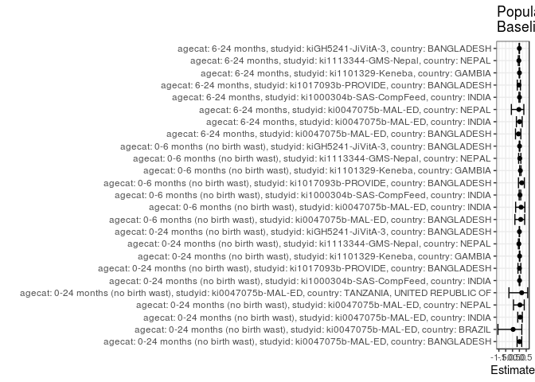

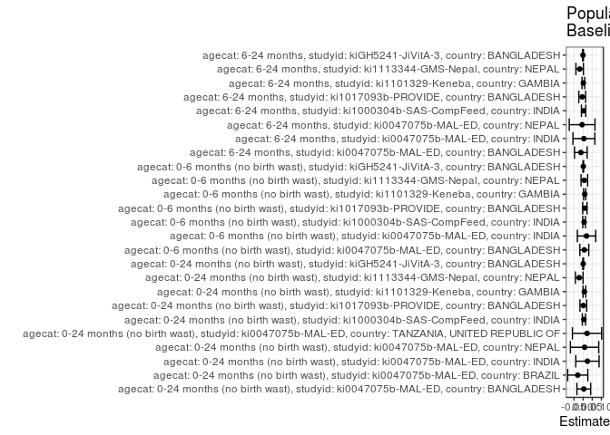

## Results Table

### Parameter: TSM

| agecat | studyid | country | intervention_level | baseline_level | estimate | ci_lower | ci_upper |
| --- | --- | --- | --- | --- | --- | --- | --- |
| 0-24 months (no birth wast) | ki0047075b-MAL-ED | BANGLADESH | 1 | NA | 0.2216783 | 0.1566670 | 0.2866896 |
| 0-24 months (no birth wast) | ki0047075b-MAL-ED | BANGLADESH | 0 | NA | 0.2163904 | 0.1277108 | 0.3050700 |
| 0-24 months (no birth wast) | ki0047075b-MAL-ED | BRAZIL | 1 | NA | 0.0937500 | 0.0221611 | 0.1653389 |
| 0-24 months (no birth wast) | ki0047075b-MAL-ED | BRAZIL | 0 | NA | 0.0507246 | 0.0140225 | 0.0874268 |
| 0-24 months (no birth wast) | ki0047075b-MAL-ED | INDIA | 1 | NA | 0.3630231 | 0.2722118 | 0.4538343 |
| 0-24 months (no birth wast) | ki0047075b-MAL-ED | INDIA | 0 | NA | 0.4155322 | 0.3174995 | 0.5135650 |
| 0-24 months (no birth wast) | ki0047075b-MAL-ED | NEPAL | 1 | NA | 0.1945706 | 0.1029905 | 0.2861507 |
| 0-24 months (no birth wast) | ki0047075b-MAL-ED | NEPAL | 0 | NA | 0.2144664 | 0.1504575 | 0.2784753 |
| 0-24 months (no birth wast) | ki0047075b-MAL-ED | TANZANIA, UNITED REPUBLIC OF | 1 | NA | 0.1063830 | 0.0180333 | 0.1947326 |
| 0-24 months (no birth wast) | ki0047075b-MAL-ED | TANZANIA, UNITED REPUBLIC OF | 0 | NA | 0.1337209 | 0.0827402 | 0.1847017 |
| 0-24 months (no birth wast) | ki1000304b-SAS-CompFeed | INDIA | 1 | NA | 0.3749192 | 0.3179202 | 0.4319182 |
| 0-24 months (no birth wast) | ki1000304b-SAS-CompFeed | INDIA | 0 | NA | 0.4616077 | 0.3160034 | 0.6072119 |
| 0-24 months (no birth wast) | ki1017093b-PROVIDE | BANGLADESH | 1 | NA | 0.1766002 | 0.1427952 | 0.2104052 |
| 0-24 months (no birth wast) | ki1017093b-PROVIDE | BANGLADESH | 0 | NA | 0.1784940 | 0.1245251 | 0.2324629 |
| 0-24 months (no birth wast) | ki1101329-Keneba | GAMBIA | 1 | NA | 0.3876237 | 0.3651272 | 0.4101201 |
| 0-24 months (no birth wast) | ki1101329-Keneba | GAMBIA | 0 | NA | 0.4508714 | 0.3859020 | 0.5158409 |
| 0-24 months (no birth wast) | ki1113344-GMS-Nepal | NEPAL | 1 | NA | 0.6106569 | 0.5615002 | 0.6598135 |
| 0-24 months (no birth wast) | ki1113344-GMS-Nepal | NEPAL | 0 | NA | 0.5059462 | 0.3953300 | 0.6165624 |
| 0-24 months (no birth wast) | kiGH5241-JiVitA-3 | BANGLADESH | 1 | NA | 0.1734398 | 0.1664836 | 0.1803961 |
| 0-24 months (no birth wast) | kiGH5241-JiVitA-3 | BANGLADESH | 0 | NA | 0.1784529 | 0.1553942 | 0.2015115 |
| 0-6 months (no birth wast) | ki0047075b-MAL-ED | BANGLADESH | 1 | NA | 0.0632911 | 0.0252469 | 0.1013354 |
| 0-6 months (no birth wast) | ki0047075b-MAL-ED | BANGLADESH | 0 | NA | 0.0823529 | 0.0237915 | 0.1409143 |
| 0-6 months (no birth wast) | ki0047075b-MAL-ED | INDIA | 1 | NA | 0.1337361 | 0.0674545 | 0.2000176 |
| 0-6 months (no birth wast) | ki0047075b-MAL-ED | INDIA | 0 | NA | 0.1830476 | 0.1045432 | 0.2615519 |
| 0-6 months (no birth wast) | ki1000304b-SAS-CompFeed | INDIA | 1 | NA | 0.1204819 | 0.0857775 | 0.1551864 |
| 0-6 months (no birth wast) | ki1000304b-SAS-CompFeed | INDIA | 0 | NA | 0.2272727 | 0.0595457 | 0.3949997 |
| 0-6 months (no birth wast) | ki1017093b-PROVIDE | BANGLADESH | 1 | NA | 0.0446723 | 0.0264003 | 0.0629443 |
| 0-6 months (no birth wast) | ki1017093b-PROVIDE | BANGLADESH | 0 | NA | 0.0791541 | 0.0406616 | 0.1176465 |
| 0-6 months (no birth wast) | ki1101329-Keneba | GAMBIA | 1 | NA | 0.1146445 | 0.0998843 | 0.1294046 |
| 0-6 months (no birth wast) | ki1101329-Keneba | GAMBIA | 0 | NA | 0.1920630 | 0.1394851 | 0.2446409 |
| 0-6 months (no birth wast) | ki1113344-GMS-Nepal | NEPAL | 1 | NA | 0.2120587 | 0.1700168 | 0.2541006 |
| 0-6 months (no birth wast) | ki1113344-GMS-Nepal | NEPAL | 0 | NA | 0.2266481 | 0.1254712 | 0.3278251 |
| 0-6 months (no birth wast) | kiGH5241-JiVitA-3 | BANGLADESH | 1 | NA | 0.0725698 | 0.0674499 | 0.0776897 |
| 0-6 months (no birth wast) | kiGH5241-JiVitA-3 | BANGLADESH | 0 | NA | 0.0832477 | 0.0655676 | 0.1009278 |
| 6-24 months | ki0047075b-MAL-ED | BANGLADESH | 1 | NA | 0.1891990 | 0.1268862 | 0.2515117 |
| 6-24 months | ki0047075b-MAL-ED | BANGLADESH | 0 | NA | 0.1436446 | 0.0650195 | 0.2222698 |
| 6-24 months | ki0047075b-MAL-ED | INDIA | 1 | NA | 0.2828069 | 0.1967681 | 0.3688458 |
| 6-24 months | ki0047075b-MAL-ED | INDIA | 0 | NA | 0.2895129 | 0.1986577 | 0.3803681 |
| 6-24 months | ki0047075b-MAL-ED | NEPAL | 1 | NA | 0.1648573 | 0.0806519 | 0.2490628 |
| 6-24 months | ki0047075b-MAL-ED | NEPAL | 0 | NA | 0.1640326 | 0.1062444 | 0.2218208 |
| 6-24 months | ki1000304b-SAS-CompFeed | INDIA | 1 | NA | 0.3140704 | 0.2638452 | 0.3642955 |
| 6-24 months | ki1000304b-SAS-CompFeed | INDIA | 0 | NA | 0.3684211 | 0.1333387 | 0.6035034 |
| 6-24 months | ki1017093b-PROVIDE | BANGLADESH | 1 | NA | 0.1658661 | 0.1308545 | 0.2008777 |
| 6-24 months | ki1017093b-PROVIDE | BANGLADESH | 0 | NA | 0.1488602 | 0.0963829 | 0.2013375 |
| 6-24 months | ki1101329-Keneba | GAMBIA | 1 | NA | 0.3422333 | 0.3197174 | 0.3647492 |
| 6-24 months | ki1101329-Keneba | GAMBIA | 0 | NA | 0.3506930 | 0.2852950 | 0.4160910 |
| 6-24 months | ki1113344-GMS-Nepal | NEPAL | 1 | NA | 0.5176816 | 0.4672024 | 0.5681607 |
| 6-24 months | ki1113344-GMS-Nepal | NEPAL | 0 | NA | 0.3757086 | 0.2653125 | 0.4861047 |
| 6-24 months | kiGH5241-JiVitA-3 | BANGLADESH | 1 | NA | 0.1692425 | 0.1609551 | 0.1775298 |
| 6-24 months | kiGH5241-JiVitA-3 | BANGLADESH | 0 | NA | 0.1605512 | 0.1335833 | 0.1875192 |

### Parameter: E(Y)

| agecat | studyid | country | intervention_level | baseline_level | estimate | ci_lower | ci_upper |
| --- | --- | --- | --- | --- | --- | --- | --- |
| 0-24 months (no birth wast) | ki0047075b-MAL-ED | BANGLADESH | NA | NA | 0.2254098 | 0.1728726 | 0.2779471 |
| 0-24 months (no birth wast) | ki0047075b-MAL-ED | BRAZIL | NA | NA | 0.0643564 | 0.0304329 | 0.0982800 |
| 0-24 months (no birth wast) | ki0047075b-MAL-ED | INDIA | NA | NA | 0.3867925 | 0.3210797 | 0.4525052 |
| 0-24 months (no birth wast) | ki0047075b-MAL-ED | NEPAL | NA | NA | 0.2026432 | 0.1502365 | 0.2550498 |
| 0-24 months (no birth wast) | ki0047075b-MAL-ED | TANZANIA, UNITED REPUBLIC OF | NA | NA | 0.1278539 | 0.0835266 | 0.1721812 |
| 0-24 months (no birth wast) | ki1000304b-SAS-CompFeed | INDIA | NA | NA | 0.3792325 | 0.3255512 | 0.4329138 |
| 0-24 months (no birth wast) | ki1017093b-PROVIDE | BANGLADESH | NA | NA | 0.1775837 | 0.1489858 | 0.2061816 |
| 0-24 months (no birth wast) | ki1101329-Keneba | GAMBIA | NA | NA | 0.3945409 | 0.3731954 | 0.4158865 |
| 0-24 months (no birth wast) | ki1113344-GMS-Nepal | NEPAL | NA | NA | 0.5894040 | 0.5440524 | 0.6347556 |
| 0-24 months (no birth wast) | kiGH5241-JiVitA-3 | BANGLADESH | NA | NA | 0.1738218 | 0.1671074 | 0.1805361 |
| 0-6 months (no birth wast) | ki0047075b-MAL-ED | BANGLADESH | NA | NA | 0.0699588 | 0.0378213 | 0.1020964 |
| 0-6 months (no birth wast) | ki0047075b-MAL-ED | INDIA | NA | NA | 0.1523810 | 0.1036572 | 0.2011047 |
| 0-6 months (no birth wast) | ki1000304b-SAS-CompFeed | INDIA | NA | NA | 0.1258581 | 0.0910745 | 0.1606418 |
| 0-6 months (no birth wast) | ki1017093b-PROVIDE | BANGLADESH | NA | NA | 0.0541728 | 0.0371844 | 0.0711612 |
| 0-6 months (no birth wast) | ki1101329-Keneba | GAMBIA | NA | NA | 0.1234383 | 0.1090221 | 0.1378544 |
| 0-6 months (no birth wast) | ki1113344-GMS-Nepal | NEPAL | NA | NA | 0.2186788 | 0.1799683 | 0.2573894 |
| 0-6 months (no birth wast) | kiGH5241-JiVitA-3 | BANGLADESH | NA | NA | 0.0735505 | 0.0685774 | 0.0785236 |
| 6-24 months | ki0047075b-MAL-ED | BANGLADESH | NA | NA | 0.1767241 | 0.1275357 | 0.2259125 |
| 6-24 months | ki0047075b-MAL-ED | INDIA | NA | NA | 0.2870813 | 0.2256006 | 0.3485621 |
| 6-24 months | ki0047075b-MAL-ED | NEPAL | NA | NA | 0.1592920 | 0.1114757 | 0.2071084 |
| 6-24 months | ki1000304b-SAS-CompFeed | INDIA | NA | NA | 0.3165468 | 0.2711185 | 0.3619751 |
| 6-24 months | ki1017093b-PROVIDE | BANGLADESH | NA | NA | 0.1609756 | 0.1319065 | 0.1900447 |
| 6-24 months | ki1101329-Keneba | GAMBIA | NA | NA | 0.3434555 | 0.3221539 | 0.3647571 |
| 6-24 months | ki1113344-GMS-Nepal | NEPAL | NA | NA | 0.4988914 | 0.4526947 | 0.5450880 |
| 6-24 months | kiGH5241-JiVitA-3 | BANGLADESH | NA | NA | 0.1684342 | 0.1604630 | 0.1764054 |

### Parameter: RR

| agecat | studyid | country | intervention_level | baseline_level | estimate | ci_lower | ci_upper |
| --- | --- | --- | --- | --- | --- | --- | --- |
| 0-24 months (no birth wast) | ki0047075b-MAL-ED | BANGLADESH | 1 | 1 | 1.0000000 | 1.0000000 | 1.0000000 |
| 0-24 months (no birth wast) | ki0047075b-MAL-ED | BANGLADESH | 0 | 1 | 0.9761459 | 0.5925778 | 1.6079925 |
| 0-24 months (no birth wast) | ki0047075b-MAL-ED | BRAZIL | 1 | 1 | 1.0000000 | 1.0000000 | 1.0000000 |
| 0-24 months (no birth wast) | ki0047075b-MAL-ED | BRAZIL | 0 | 1 | 0.5410628 | 0.1889656 | 1.5492185 |
| 0-24 months (no birth wast) | ki0047075b-MAL-ED | INDIA | 1 | 1 | 1.0000000 | 1.0000000 | 1.0000000 |
| 0-24 months (no birth wast) | ki0047075b-MAL-ED | INDIA | 0 | 1 | 1.1446441 | 0.8109300 | 1.6156884 |
| 0-24 months (no birth wast) | ki0047075b-MAL-ED | NEPAL | 1 | 1 | 1.0000000 | 1.0000000 | 1.0000000 |
| 0-24 months (no birth wast) | ki0047075b-MAL-ED | NEPAL | 0 | 1 | 1.1022549 | 0.6318572 | 1.9228488 |
| 0-24 months (no birth wast) | ki0047075b-MAL-ED | TANZANIA, UNITED REPUBLIC OF | 1 | 1 | 1.0000000 | 1.0000000 | 1.0000000 |
| 0-24 months (no birth wast) | ki0047075b-MAL-ED | TANZANIA, UNITED REPUBLIC OF | 0 | 1 | 1.2569767 | 0.5040371 | 3.1346711 |
| 0-24 months (no birth wast) | ki1000304b-SAS-CompFeed | INDIA | 1 | 1 | 1.0000000 | 1.0000000 | 1.0000000 |
| 0-24 months (no birth wast) | ki1000304b-SAS-CompFeed | INDIA | 0 | 1 | 1.2312191 | 0.8795361 | 1.7235226 |
| 0-24 months (no birth wast) | ki1017093b-PROVIDE | BANGLADESH | 1 | 1 | 1.0000000 | 1.0000000 | 1.0000000 |
| 0-24 months (no birth wast) | ki1017093b-PROVIDE | BANGLADESH | 0 | 1 | 1.0107236 | 0.7068317 | 1.4452696 |
| 0-24 months (no birth wast) | ki1101329-Keneba | GAMBIA | 1 | 1 | 1.0000000 | 1.0000000 | 1.0000000 |
| 0-24 months (no birth wast) | ki1101329-Keneba | GAMBIA | 0 | 1 | 1.1631680 | 0.9964944 | 1.3577195 |
| 0-24 months (no birth wast) | ki1113344-GMS-Nepal | NEPAL | 1 | 1 | 1.0000000 | 1.0000000 | 1.0000000 |
| 0-24 months (no birth wast) | ki1113344-GMS-Nepal | NEPAL | 0 | 1 | 0.8285278 | 0.6573547 | 1.0442739 |
| 0-24 months (no birth wast) | kiGH5241-JiVitA-3 | BANGLADESH | 1 | 1 | 1.0000000 | 1.0000000 | 1.0000000 |
| 0-24 months (no birth wast) | kiGH5241-JiVitA-3 | BANGLADESH | 0 | 1 | 1.0289034 | 0.8995885 | 1.1768072 |
| 0-6 months (no birth wast) | ki0047075b-MAL-ED | BANGLADESH | 1 | 1 | 1.0000000 | 1.0000000 | 1.0000000 |
| 0-6 months (no birth wast) | ki0047075b-MAL-ED | BANGLADESH | 0 | 1 | 1.3011765 | 0.5128087 | 3.3015437 |
| 0-6 months (no birth wast) | ki0047075b-MAL-ED | INDIA | 1 | 1 | 1.0000000 | 1.0000000 | 1.0000000 |
| 0-6 months (no birth wast) | ki0047075b-MAL-ED | INDIA | 0 | 1 | 1.3687224 | 0.7076299 | 2.6474304 |
| 0-6 months (no birth wast) | ki1000304b-SAS-CompFeed | INDIA | 1 | 1 | 1.0000000 | 1.0000000 | 1.0000000 |
| 0-6 months (no birth wast) | ki1000304b-SAS-CompFeed | INDIA | 0 | 1 | 1.8863636 | 0.8915751 | 3.9911028 |
| 0-6 months (no birth wast) | ki1017093b-PROVIDE | BANGLADESH | 1 | 1 | 1.0000000 | 1.0000000 | 1.0000000 |
| 0-6 months (no birth wast) | ki1017093b-PROVIDE | BANGLADESH | 0 | 1 | 1.7718827 | 0.9382202 | 3.3463021 |
| 0-6 months (no birth wast) | ki1101329-Keneba | GAMBIA | 1 | 1 | 1.0000000 | 1.0000000 | 1.0000000 |
| 0-6 months (no birth wast) | ki1101329-Keneba | GAMBIA | 0 | 1 | 1.6752922 | 1.2386541 | 2.2658498 |
| 0-6 months (no birth wast) | ki1113344-GMS-Nepal | NEPAL | 1 | 1 | 1.0000000 | 1.0000000 | 1.0000000 |
| 0-6 months (no birth wast) | ki1113344-GMS-Nepal | NEPAL | 0 | 1 | 1.0687992 | 0.6553493 | 1.7430885 |
| 0-6 months (no birth wast) | kiGH5241-JiVitA-3 | BANGLADESH | 1 | 1 | 1.0000000 | 1.0000000 | 1.0000000 |
| 0-6 months (no birth wast) | kiGH5241-JiVitA-3 | BANGLADESH | 0 | 1 | 1.1471399 | 0.9189574 | 1.4319814 |
| 6-24 months | ki0047075b-MAL-ED | BANGLADESH | 1 | 1 | 1.0000000 | 1.0000000 | 1.0000000 |
| 6-24 months | ki0047075b-MAL-ED | BANGLADESH | 0 | 1 | 0.7592252 | 0.4027906 | 1.4310735 |
| 6-24 months | ki0047075b-MAL-ED | INDIA | 1 | 1 | 1.0000000 | 1.0000000 | 1.0000000 |
| 6-24 months | ki0047075b-MAL-ED | INDIA | 0 | 1 | 1.0237121 | 0.6607545 | 1.5860452 |
| 6-24 months | ki0047075b-MAL-ED | NEPAL | 1 | 1 | 1.0000000 | 1.0000000 | 1.0000000 |
| 6-24 months | ki0047075b-MAL-ED | NEPAL | 0 | 1 | 0.9949971 | 0.5352273 | 1.8497174 |
| 6-24 months | ki1000304b-SAS-CompFeed | INDIA | 1 | 1 | 1.0000000 | 1.0000000 | 1.0000000 |
| 6-24 months | ki1000304b-SAS-CompFeed | INDIA | 0 | 1 | 1.1730526 | 0.5767231 | 2.3859846 |
| 6-24 months | ki1017093b-PROVIDE | BANGLADESH | 1 | 1 | 1.0000000 | 1.0000000 | 1.0000000 |
| 6-24 months | ki1017093b-PROVIDE | BANGLADESH | 0 | 1 | 0.8974721 | 0.5948133 | 1.3541328 |
| 6-24 months | ki1101329-Keneba | GAMBIA | 1 | 1 | 1.0000000 | 1.0000000 | 1.0000000 |
| 6-24 months | ki1101329-Keneba | GAMBIA | 0 | 1 | 1.0247191 | 0.8410295 | 1.2485283 |
| 6-24 months | ki1113344-GMS-Nepal | NEPAL | 1 | 1 | 1.0000000 | 1.0000000 | 1.0000000 |
| 6-24 months | ki1113344-GMS-Nepal | NEPAL | 0 | 1 | 0.7257524 | 0.5333882 | 0.9874919 |
| 6-24 months | kiGH5241-JiVitA-3 | BANGLADESH | 1 | 1 | 1.0000000 | 1.0000000 | 1.0000000 |
| 6-24 months | kiGH5241-JiVitA-3 | BANGLADESH | 0 | 1 | 0.9486462 | 0.7971129 | 1.1289865 |

### Parameter: PAR

| agecat | studyid | country | intervention_level | baseline_level | estimate | ci_lower | ci_upper |
| --- | --- | --- | --- | --- | --- | --- | --- |
| 0-24 months (no birth wast) | ki0047075b-MAL-ED | BANGLADESH | 1 | NA | 0.0037315 | -0.0340050 | 0.0414680 |
| 0-24 months (no birth wast) | ki0047075b-MAL-ED | BRAZIL | 1 | NA | -0.0293936 | -0.0844233 | 0.0256361 |
| 0-24 months (no birth wast) | ki0047075b-MAL-ED | INDIA | 1 | NA | 0.0237694 | -0.0399034 | 0.0874421 |
| 0-24 months (no birth wast) | ki0047075b-MAL-ED | NEPAL | 1 | NA | 0.0080726 | -0.0694543 | 0.0855994 |
| 0-24 months (no birth wast) | ki0047075b-MAL-ED | TANZANIA, UNITED REPUBLIC OF | 1 | NA | 0.0214709 | -0.0586552 | 0.1015970 |
| 0-24 months (no birth wast) | ki1000304b-SAS-CompFeed | INDIA | 1 | NA | 0.0043133 | -0.0046855 | 0.0133121 |
| 0-24 months (no birth wast) | ki1017093b-PROVIDE | BANGLADESH | 1 | NA | 0.0009835 | -0.0173878 | 0.0193548 |
| 0-24 months (no birth wast) | ki1101329-Keneba | GAMBIA | 1 | NA | 0.0069173 | -0.0005588 | 0.0143934 |
| 0-24 months (no birth wast) | ki1113344-GMS-Nepal | NEPAL | 1 | NA | -0.0212529 | -0.0420389 | -0.0004669 |
| 0-24 months (no birth wast) | kiGH5241-JiVitA-3 | BANGLADESH | 1 | NA | 0.0003819 | -0.0018645 | 0.0026283 |
| 0-6 months (no birth wast) | ki0047075b-MAL-ED | BANGLADESH | 1 | NA | 0.0066677 | -0.0177867 | 0.0311221 |
| 0-6 months (no birth wast) | ki0047075b-MAL-ED | INDIA | 1 | NA | 0.0186449 | -0.0315675 | 0.0688572 |
| 0-6 months (no birth wast) | ki1000304b-SAS-CompFeed | INDIA | 1 | NA | 0.0053762 | -0.0018898 | 0.0126422 |
| 0-6 months (no birth wast) | ki1017093b-PROVIDE | BANGLADESH | 1 | NA | 0.0095005 | -0.0024006 | 0.0214015 |
| 0-6 months (no birth wast) | ki1101329-Keneba | GAMBIA | 1 | NA | 0.0087938 | 0.0027916 | 0.0147960 |
| 0-6 months (no birth wast) | ki1113344-GMS-Nepal | NEPAL | 1 | NA | 0.0066201 | -0.0114427 | 0.0246830 |
| 0-6 months (no birth wast) | kiGH5241-JiVitA-3 | BANGLADESH | 1 | NA | 0.0009807 | -0.0007544 | 0.0027158 |
| 6-24 months | ki0047075b-MAL-ED | BANGLADESH | 1 | NA | -0.0124748 | -0.0471073 | 0.0221576 |
| 6-24 months | ki0047075b-MAL-ED | INDIA | 1 | NA | 0.0042744 | -0.0557603 | 0.0643091 |
| 6-24 months | ki0047075b-MAL-ED | NEPAL | 1 | NA | -0.0055653 | -0.0759793 | 0.0648487 |
| 6-24 months | ki1000304b-SAS-CompFeed | INDIA | 1 | NA | 0.0024764 | -0.0094430 | 0.0143959 |
| 6-24 months | ki1017093b-PROVIDE | BANGLADESH | 1 | NA | -0.0048905 | -0.0233935 | 0.0136125 |
| 6-24 months | ki1101329-Keneba | GAMBIA | 1 | NA | 0.0012222 | -0.0063200 | 0.0087644 |
| 6-24 months | ki1113344-GMS-Nepal | NEPAL | 1 | NA | -0.0187902 | -0.0393708 | 0.0017904 |
| 6-24 months | kiGH5241-JiVitA-3 | BANGLADESH | 1 | NA | -0.0008083 | -0.0032255 | 0.0016089 |

### Parameter: PAF

| agecat | studyid | country | intervention_level | baseline_level | estimate | ci_lower | ci_upper |
| --- | --- | --- | --- | --- | --- | --- | --- |
| 0-24 months (no birth wast) | ki0047075b-MAL-ED | BANGLADESH | 1 | NA | 0.0165544 | -0.1660534 | 0.1705652 |
| 0-24 months (no birth wast) | ki0047075b-MAL-ED | BRAZIL | 1 | NA | -0.4567308 | -1.5709361 | 0.1745946 |
| 0-24 months (no birth wast) | ki0047075b-MAL-ED | INDIA | 1 | NA | 0.0614525 | -0.1186913 | 0.2125877 |
| 0-24 months (no birth wast) | ki0047075b-MAL-ED | NEPAL | 1 | NA | 0.0398364 | -0.4296865 | 0.3551634 |
| 0-24 months (no birth wast) | ki0047075b-MAL-ED | TANZANIA, UNITED REPUBLIC OF | 1 | NA | 0.1679331 | -0.7627614 | 0.6072439 |
| 0-24 months (no birth wast) | ki1000304b-SAS-CompFeed | INDIA | 1 | NA | 0.0113737 | -0.0131809 | 0.0353333 |
| 0-24 months (no birth wast) | ki1017093b-PROVIDE | BANGLADESH | 1 | NA | 0.0055383 | -0.1034782 | 0.1037846 |
| 0-24 months (no birth wast) | ki1101329-Keneba | GAMBIA | 1 | NA | 0.0175325 | -0.0016080 | 0.0363073 |
| 0-24 months (no birth wast) | ki1113344-GMS-Nepal | NEPAL | 1 | NA | -0.0360583 | -0.0721540 | -0.0011778 |
| 0-24 months (no birth wast) | kiGH5241-JiVitA-3 | BANGLADESH | 1 | NA | 0.0021972 | -0.0108058 | 0.0150330 |
| 0-6 months (no birth wast) | ki0047075b-MAL-ED | BANGLADESH | 1 | NA | 0.0953090 | -0.3278890 | 0.3836339 |
| 0-6 months (no birth wast) | ki0047075b-MAL-ED | INDIA | 1 | NA | 0.1223571 | -0.2750822 | 0.3959157 |
| 0-6 months (no birth wast) | ki1000304b-SAS-CompFeed | INDIA | 1 | NA | 0.0427163 | -0.0166271 | 0.0985957 |
| 0-6 months (no birth wast) | ki1017093b-PROVIDE | BANGLADESH | 1 | NA | 0.1753734 | -0.0681471 | 0.3633751 |
| 0-6 months (no birth wast) | ki1101329-Keneba | GAMBIA | 1 | NA | 0.0712405 | 0.0218895 | 0.1181015 |
| 0-6 months (no birth wast) | ki1113344-GMS-Nepal | NEPAL | 1 | NA | 0.0302734 | -0.0558970 | 0.1094115 |
| 0-6 months (no birth wast) | kiGH5241-JiVitA-3 | BANGLADESH | 1 | NA | 0.0133338 | -0.0104764 | 0.0365828 |
| 6-24 months | ki0047075b-MAL-ED | BANGLADESH | 1 | NA | -0.0705893 | -0.2849945 | 0.1080418 |
| 6-24 months | ki0047075b-MAL-ED | INDIA | 1 | NA | 0.0148892 | -0.2181255 | 0.2033306 |
| 6-24 months | ki0047075b-MAL-ED | NEPAL | 1 | NA | -0.0349378 | -0.5869497 | 0.3250598 |
| 6-24 months | ki1000304b-SAS-CompFeed | INDIA | 1 | NA | 0.0078232 | -0.0309120 | 0.0451030 |
| 6-24 months | ki1017093b-PROVIDE | BANGLADESH | 1 | NA | -0.0303802 | -0.1519065 | 0.0783250 |
| 6-24 months | ki1101329-Keneba | GAMBIA | 1 | NA | 0.0035586 | -0.0186435 | 0.0252767 |
| 6-24 months | ki1113344-GMS-Nepal | NEPAL | 1 | NA | -0.0376640 | -0.0799189 | 0.0029376 |
| 6-24 months | kiGH5241-JiVitA-3 | BANGLADESH | 1 | NA | -0.0047988 | -0.0192590 | 0.0094562 |